# The Economics Behind Horror

How does the length of a horror movie impact its success?

Author

Xavier Hector

## Exploration

A common criticism among horror movie enthusiasts is the genre’s often ineffective run time. Many argue that horror films are either too long and drag out the plot, or too short and rely heavily on jump scares without developing a meaningful storyline. As public attention spans continue to shrink, with 15-second TikTok videos and YouTube Shorts gaining popularity, even 15-minute videos are sometimes considered too long, prompting the relevant question: to what extent does the length of a horror movie impact its success?

To answer this question, I will focus on the following variables from the data set: `runtime`, `vote_average`, `vote_count`, `popularity`, and `revenue`.

### Libraries, Imports and Data Wrangling

```r
library(tidyverse)
library(readr)
library(gt)
horror_movies <-  read_csv("horror_movies.csv")

horror_movies_sm <- horror_movies |>
                  select(title,
                         runtime,
                         vote_average,
                         vote_count,
                         popularity,
                         revenue) |>
                  arrange(revenue)

horror_movies_sm |>
  head (10) |>
  gt() |>
  tab_header(title = "Horror Movies by Revenue",
             subtitle = "Lowest revenue films (first 10 observations)") |>
  cols_label(title = "Movie Title",
             runtime = "Runtime",
             vote_average = "Avg Rating",
             vote_count = "Votes",
             popularity = "Popularity",
             revenue = "Revenue ($)") |>
  cols_align( align = "center",
              everything())
```

Horror Movies by Revenue

Lowest revenue films (first 10 observations)

| Movie Title | Runtime | Avg Rating | Votes | Popularity | Revenue ($) |
| --- | --- | --- | --- | --- | --- |
| Presences | 0 | 7.0 | 83 | 1020.995 | 0 |
| Sonríe | 0 | 1.0 | 1 | 939.712 | 0 |
| Hunting Ava Bravo | 90 | 6.5 | 73 | 574.832 | 0 |
| The Exorcism of God | 98 | 7.3 | 637 | 537.252 | 0 |
| The Jack in the Box: Awakening | 89 | 6.4 | 157 | 527.579 | 0 |
| Torn Hearts | 97 | 6.1 | 39 | 525.876 | 0 |
| The Cellar | 94 | 6.6 | 257 | 513.757 | 0 |
| My Best Friend's Exorcism | 96 | 6.1 | 43 | 501.921 | 0 |
| Day Shift | 113 | 6.9 | 1129 | 449.683 | 0 |
| Beneath the Surface | 93 | 6.9 | 50 | 412.340 | 0 |

After cleaning the data and keeping the variables needed for the exploration, I noticed that there are unexpected values. Many movies have revenues and run times that were 0, with many also having very low vote counts. A quick Google search was able to verify that those values were abnormal. For example, **Presences[^1]**, had $1.1 million in gross revenue and a run time of 85mn.

### More Data Cleaning

```r
horror_movies_sm <- horror_movies |>
                            select(title,
                                   runtime,
                                   vote_average,
                                   vote_count,
                                   popularity,
                                   revenue) |>
                            arrange(revenue) |>
                            mutate(revenue = na_if(revenue, 0),
                                   runtime = na_if(runtime, 0),
                                   runtime_group = case_when(runtime < 60 ~ "Short Movie",
                                                             runtime >= 60 & runtime <= 100 ~ "Medium-Length Movie",
                                                             runtime > 100 ~ "Long Movie"))

horror_movies_sm_summarized <- horror_movies_sm |>
                            summarise(total_votes = sum(vote_count, na.rm = TRUE),
                                      avg_rating = mean(vote_average, na.rm = TRUE),
                                      avg_popularity = mean(popularity, na.rm = TRUE),
                                      log_avg_revenue = log(mean(revenue, na.rm = TRUE)),
                                      n = n(),
                                      .by = runtime_group)

 horror_movies_sm_summarized |>
   arrange(desc(n)) |>
   gt() |>
  tab_header(title = "Horror Movies Summary by Runtime Group") |>
  cols_label(runtime_group = "Runtime Category",
             total_votes = "Total Votes",
             avg_rating = "Average Rating",
             avg_popularity = "Average Popularity",
             log_avg_revenue = "Log Avg Revenue",
             n = "Number of Movies") |>
  cols_align(align = "center",
             everything())
```

Horror Movies Summary by Runtime Group

| Runtime Category | Total Votes | Average Rating | Average Popularity | Log Avg Revenue | Number of Movies |
| --- | --- | --- | --- | --- | --- |
| Medium-Length Movie | 1152200 | 3.835330 | 5.0088401 | 16.83810 | 17365 |
| Short Movie | 22596 | 2.525824 | 0.9076265 | 12.43710 | 9135 |
| Long Movie | 862521 | 4.284282 | 8.9430472 | 17.69903 | 3372 |
| NA | 2664 | 1.658208 | 1.9386106 | 14.24714 | 2668 |

I then decided to convert all the values with `revenue` and `runtime` that were equal to 0 into `NA` in order to reduce noise in the data. Since this project is focused on run time, I also chose to divide the movies into three distinct groups:

```
  . `runtime` < 60 : Short Movie

  . 60 <=`runtime`<= 100: Medium-Length Movie

  . `runtime` > 100 : Long Movie
```

Although there are no official categories that exist to classify movies by run time, the method chosen was judged ‘fair’ based on the counts that were available in each category. To further reduce the influence of potential outliers, I used the log average of revenues, which helped stabilize extreme values and provided a more balanced comparison across categories.

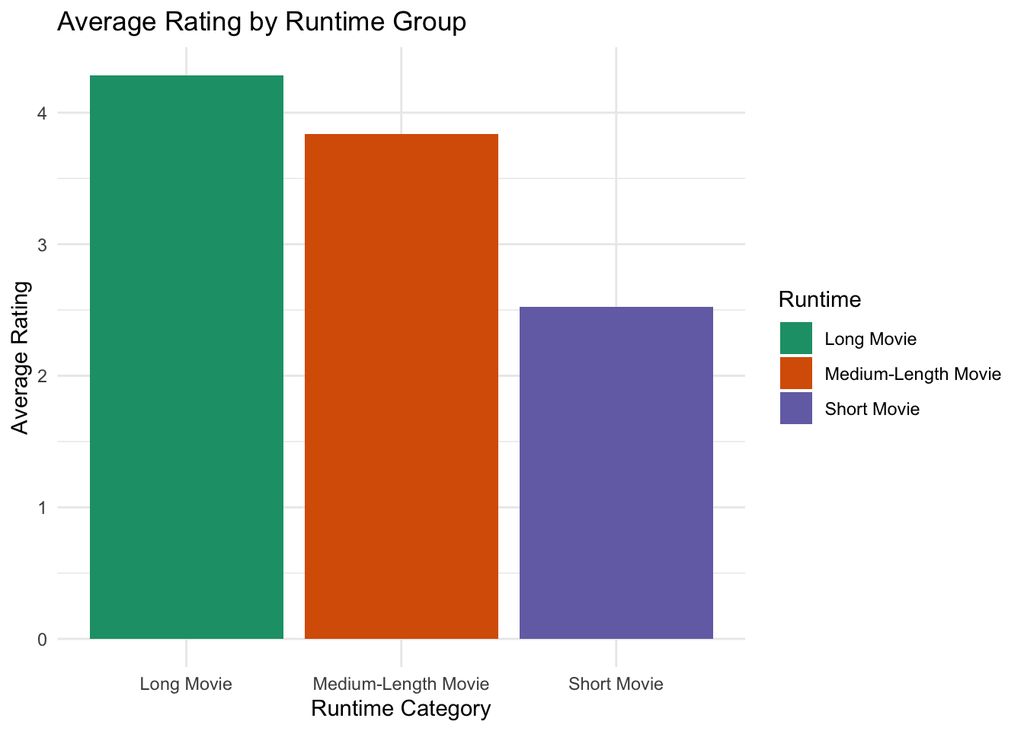

```r
horror_movies_sm_summarized |>
  filter(!is.na(runtime_group)) |>
  ggplot(aes(x = runtime_group,
             y = avg_rating,
             fill = runtime_group)) +
  geom_col() +
  scale_fill_brewer(palette = "Dark2")+
  labs(title = "Average Rating by Runtime Group",
       x = "Runtime Category",
       y = "Average Rating",
       fill = "Runtime") +
  theme_minimal()
```

This bar graph shows that on average, longer movies tend to be higher rated than other categories. It also shows that average ratings go down as `runtime` decreases.

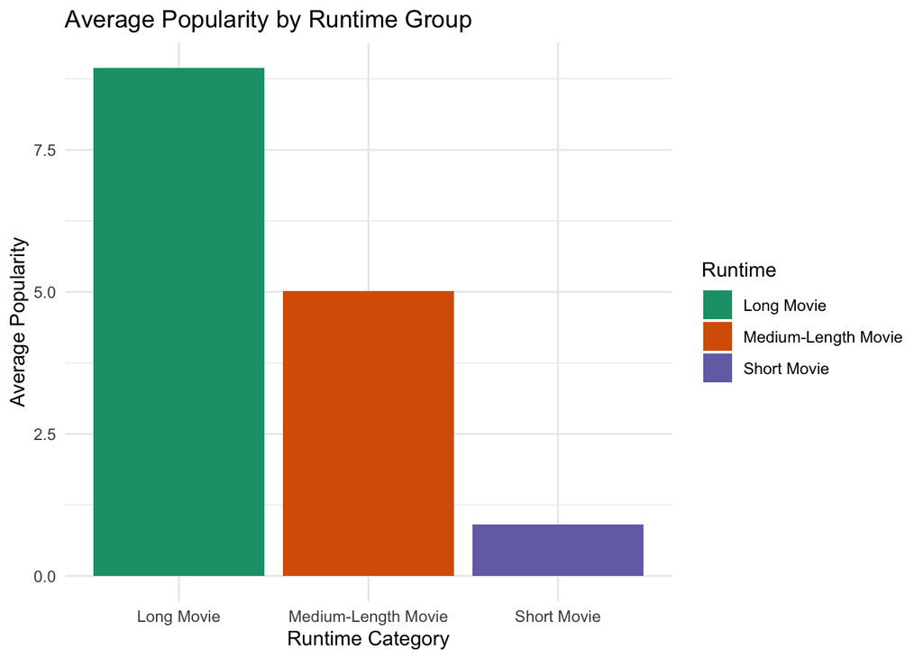

```r
horror_movies_sm_summarized |>
  filter(!is.na(runtime_group)) |>
  ggplot(aes(x = runtime_group,
             y = avg_popularity,
             fill = runtime_group)) +
  geom_col() +
  scale_fill_brewer(palette = "Dark2")+
  labs(title = "Average Popularity by Runtime Group",
       x = "Runtime Category",
       y = "Average Popularity",
       fill = "Runtime") +
  theme_minimal()
```

The same relationship is observed for popularity, which appears to contradict the common belief that the general public’s attention span is decreasing. This suggests that, at least within this data set, longer horror movies may still perform well in terms of audience interest. It may also challenge the stigma surrounding film length, indicating that viewers do not necessarily prefer shorter movies and may, in fact, be more engaged by longer horror films even when the plot is dragged.

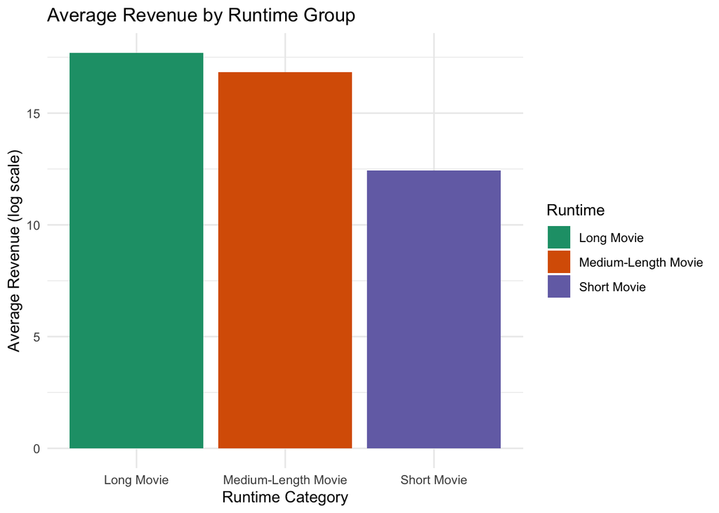

```r
horror_movies_sm_summarized |>
  filter(!is.na(runtime_group)) |>
  ggplot(aes(x = runtime_group,
           y = log_avg_revenue,
           fill = runtime_group)) +
  geom_col() +
  scale_fill_brewer(palette = "Dark2")+
  labs(title = "Average Revenue by Runtime Group",
       x = "Runtime Category",
       y = "Average Revenue (log scale)",
       fill = "Runtime") +
  theme_minimal()
```

As money is usually the measure of success for the box office, the Average Revenue graph also shows that revenues tend to decrease as run time goes down. However, it is important to note that the average revenue difference between long and medium length movies is small considering the big gap in popularity between the two.

```r
horror_movies_sm |>
  filter(!is.na(revenue), !is.na(runtime_group)) |>
  group_by(runtime_group) |>
  slice_max(revenue, n = 3) |>
  ungroup() |>
  arrange(runtime_group, desc(revenue)) |>
  gt() |>
  tab_header(title = "Top 3 Revenue Movies by Runtime Group") |>
  tab_row_group(label = "Short Movies",
                rows = runtime_group == "Short Movie") |>
  tab_row_group(label = "Medium-Length Movies",
                rows = runtime_group == "Medium-Length Movie") |>
  tab_row_group(label = "Long Movies",
                rows = runtime_group == "Long Movie") |>
  cols_label(title = "Movie Title",
             runtime = "Runtime",
             revenue = "Revenue ($)",
             runtime_group = "Runtime Category") |>
  cols_hide(columns = runtime_group) |>
  cols_align(align = "center", everything())
```

Top 3 Revenue Movies by Runtime Group

| Movie Title | Runtime | vote_average | vote_count | popularity | Revenue ($) |
| --- | --- | --- | --- | --- | --- |
| Long Movies |  |  |  |  |  |
| It | 135 | 7.2 | 16900 | 106.786 | 701842551 |
| World War Z | 116 | 6.8 | 13440 | 131.399 | 531865000 |
| The Meg | 113 | 6.2 | 6068 | 116.512 | 530243742 |
| Medium-Length Movies |  |  |  |  |  |
| The Nun | 96 | 5.8 | 5393 | 131.032 | 365550119 |
| A Quiet Place | 91 | 7.4 | 12032 | 63.493 | 340677200 |
| Resident Evil: Afterlife | 97 | 6.1 | 3274 | 1.916 | 300228084 |
| Short Movies |  |  |  |  |  |
| Haunted Castle | 38 | 5.2 | 6 | 1.096 | 13651656 |
| Semen Demon | 56 | 6.1 | 11 | 3.282 | 1000000 |
| Bear Lake Bloodbath | 12 | 0.0 | 0 | 0.600 | 1000000 |

## Conclusion

Despite the common criticism about the public’s attention span decreasing, this data set seems to show a direct relationship between the run time of horror movies and their revenue, ratings, and popularity. According to an article by **[The Hollywood Reporter](https://www.hollywoodreporter.com/movies/movie-features/oscar-voters-longer-films-analysis-1236066381/)[^2]**, even Oscar voters are favoring longer movies. Although their argument applies to all films, it is not unreasonable to extrapolate that the artistic world values depth and length over pure profit that can be found in shorter videos. While many things in the world are becoming shorter and more efficient, people seem to prefer their movies to be “endless, languorous, indulgent.” This exploration shows that horror movies are no exception: despite being one of the genres heavily criticized for run time, the data indicates that on average, audiences **DO** prefer a plot that lingers, rather than relying solely on jump scares.

In this exploration, some decisions were made not for technical reasons, but primarily to maintain balance in the data set. However, these choices could have potentially influenced the results of the project, particularly transforming 0 values into `NA` and arbitrarily setting the caps for the run time categories. For future reference, performing data wrangling for technical reasons may improve the reliability of the analysis. While the rationale for these choices was not strictly technical, I still believe that the results are pretty reliable.

## Footnotes

[^1]: Presences : The first observation in the **Horror Movies By Revenue** plot.
[^2]: A [magazine](https://www.hollywoodreporter.com/) that focuses on the film, television, theatre, and entertainment industries.